# Predicción de la Esperanza de vida ¿El consumo de alcohol alarga la vida?

Análisis Exploratorio de Datos. Máster en Ciencia de Datos - UV

Sergio Conde

# Librerías cargadas

```
 [1] ".GlobalEnv"        "package:car"       "package:carData"   "package:gridExtra"
 [5] "package:ggplot2"   "package:mice"      "package:dplyr"     "package:leaps"
 [9] "package:knitr"     "package:stats"     "package:graphics"  "package:grDevices"
[13] "package:utils"     "package:datasets"  "package:methods"   "Autoloads"
[17] "package:base"
```

# Importación y preparación de los datos

Comenzamos importando los datos y transformando la variable Status de character a factor, además de eliminar la columna population debido a los errores en sus datos:

```r
load("EV2014.RData")
EV2014$Status <- factor(EV2014$Status, levels = c('Developing', 'Developed'), labels = c(0,1))
EV2014 <- select(EV2014, -Population)

load("EV2015.RData")
EV2015$Status <- factor(EV2015$Status, levels = c('Developing', 'Developed'), labels = c(0,1))
EV2015 <- select(EV2015, -Population)
NAdata <- EV2014[rowSums(is.na(EV2014)) > 0, ]
#View(EV2014)
```

# Parte 1

## Imputación de datos

Observamos que los datos con NA componen un 21.3114754% del total de los datos, además de estar compuestos en su mayoría por países en desarrollo. Es decir, se trata de datos “Missing at Random”. Por tanto, lo lógico es buscar una manera para imputar dichos datos. En nuestro caso, utilizaremos la librería mice.

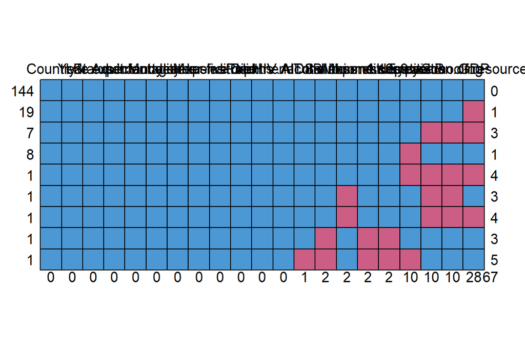

```
    Country Year Status Life.expectancy Adult.Mortality infant.deaths percentage.expenditure
144       1    1      1               1               1             1                      1
19        1    1      1               1               1             1                      1
7         1    1      1               1               1             1                      1
8         1    1      1               1               1             1                      1
1         1    1      1               1               1             1                      1
1         1    1      1               1               1             1                      1
1         1    1      1               1               1             1                      1
1         1    1      1               1               1             1                      1
1         1    1      1               1               1             1                      1
          0    0      0               0               0             0                      0
    Measles under.five.deaths Polio Diphtheria HIV.AIDS Alcohol BMI Total.expenditure
144       1                 1     1          1        1       1   1                 1
19        1                 1     1          1        1       1   1                 1
7         1                 1     1          1        1       1   1                 1
```

[output cut: 29 more lines]

En la imagen anterior observamos que la mayor cantidad de datos perdidos se encuentra en la variable GDP con 28 NA. Procedemos ahora a la importación con ayuda del paquete *Mice*.

```r
mice_imputes = mice(EV2014, m=1, maxit = 50, seed = 500)
```

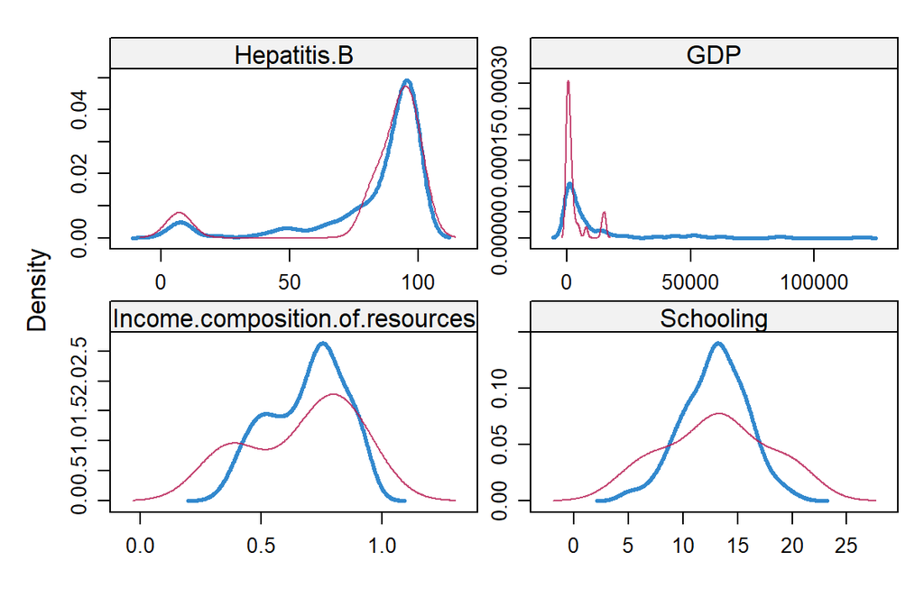

## BIC

Usamos la funcion regsubsets, que probará todos los modelos con hasta 18 variables y nos ayudará a sacar el modelo con menor BIC

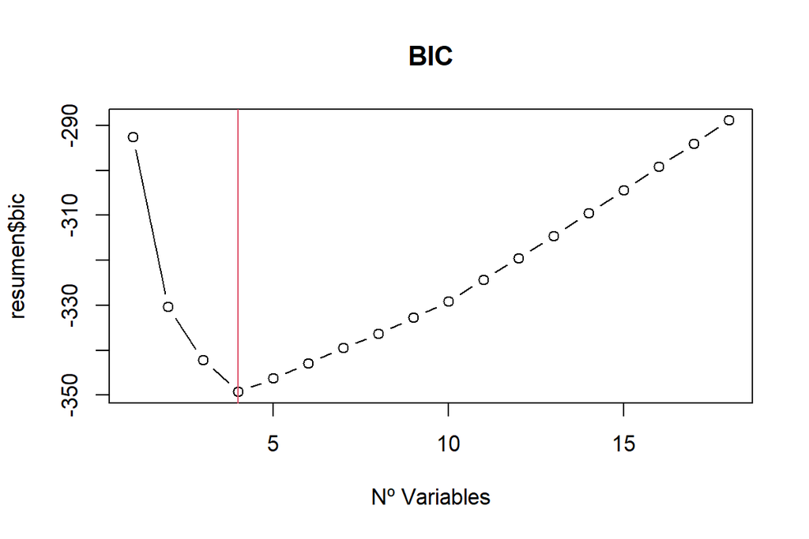

Obtenemos pues, que el número ideal de variables a utilizar será 4. En concreto, Adult.Mortality, Total.expenditure, HIV-AIDS e Income.composition.of.resources. Vamos ahora a compararlo con el método stepwise.

## Stepwise

```
Call:
lm(formula = Life.expectancy ~ Adult.Mortality + infant.deaths +
    percentage.expenditure + under.five.deaths + Total.expenditure +
    Diphtheria + HIV.AIDS + Income.composition.of.resources,
    data = Imputed_data)

Residuals:
     Min       1Q   Median       3Q      Max
-11.5210  -1.7133  -0.4225   1.5697   9.6356

Coefficients:
                                  Estimate Std. Error t value Pr(>|t|)
(Intercept)                      4.736e+01  1.935e+00  24.471  < 2e-16 ***
Adult.Mortality                 -1.372e-02  3.348e-03  -4.097 6.40e-05 ***
infant.deaths                    5.021e-02  2.910e-02   1.725  0.08624 .
percentage.expenditure           1.434e-04  9.976e-05   1.437  0.15241
under.five.deaths               -4.010e-02  2.229e-02  -1.799  0.07371 .
Total.expenditure                2.768e-01  8.739e-02   3.167  0.00182 **
Diphtheria                       1.509e-02  1.074e-02   1.405  0.16166
HIV.AIDS                        -9.585e-01  2.143e-01  -4.473 1.39e-05 ***
Income.composition.of.resources  3.468e+01  2.234e+00  15.527  < 2e-16 ***
---
Signif. codes:  0 '***' 0.001 '**' 0.01 '*' 0.05 '.' 0.1 ' ' 1

Residual standard error: 3.073 on 174 degrees of freedom
Multiple R-squared:  0.8768,    Adjusted R-squared:  0.8712
F-statistic: 154.8 on 8 and 174 DF,  p-value: < 2.2e-16
```

```
Call:
lm(formula = Life.expectancy ~ Adult.Mortality + Total.expenditure +
    HIV.AIDS + Income.composition.of.resources, data = Imputed_data)

Residuals:
     Min       1Q   Median       3Q      Max
-11.1483  -1.8331  -0.2951   1.5132   9.7990

Coefficients:
                                 Estimate Std. Error t value Pr(>|t|)
(Intercept)                     47.210330   1.753555  26.923  < 2e-16 ***
Adult.Mortality                 -0.014381   0.003365  -4.274 3.13e-05 ***
Total.expenditure                0.306174   0.087041   3.518 0.000553 ***
HIV.AIDS                        -0.995496   0.213912  -4.654 6.35e-06 ***
Income.composition.of.resources 36.737468   2.054054  17.885  < 2e-16 ***
---
Signif. codes:  0 '***' 0.001 '**' 0.01 '*' 0.05 '.' 0.1 ' ' 1

Residual standard error: 3.105 on 178 degrees of freedom
Multiple R-squared:  0.8714,    Adjusted R-squared:  0.8685
F-statistic: 301.4 on 4 and 178 DF,  p-value: < 2.2e-16
```

Obtenemos un modelo que explica una cantidad muy similar en los dos casos, pero como en el segundo caso tenemos todas las variables con un p-valor significativo, partiremos de ese modelo e intentaremos hacer alguna transformación para mejorarlo.

## Modelo final

```
Call:
lm(formula = (Life.expectancy ~ Total.expenditure + poly(HIV.AIDS,
    2) + poly(Adult.Mortality, 2) + poly(Income.composition.of.resources,
    2)), data = Imputed_data)

Residuals:
    Min      1Q  Median      3Q     Max
-8.6778 -1.6227 -0.4486  1.2867  9.9405

Coefficients:
                                           Estimate Std. Error t value Pr(>|t|)
(Intercept)                                69.58947    0.54839 126.897  < 2e-16 ***
Total.expenditure                           0.31470    0.08161   3.856 0.000162 ***
poly(HIV.AIDS, 2)1                         -7.32339    4.80786  -1.523 0.129510
poly(HIV.AIDS, 2)2                         14.40051    3.40128   4.234 3.70e-05 ***
poly(Adult.Mortality, 2)1                 -31.63661    5.02682  -6.294 2.42e-09 ***
poly(Adult.Mortality, 2)2                 -18.82674    4.16548  -4.520 1.14e-05 ***
poly(Income.composition.of.resources, 2)1  70.20977    4.39930  15.959  < 2e-16 ***
poly(Income.composition.of.resources, 2)2  10.28818    3.16856   3.247 0.001398 **
---
Signif. codes:  0 '***' 0.001 '**' 0.01 '*' 0.05 '.' 0.1 ' ' 1

Residual standard error: 2.895 on 175 degrees of freedom
Multiple R-squared:  0.8901,    Adjusted R-squared:  0.8857
F-statistic: 202.4 on 7 and 175 DF,  p-value: < 2.2e-16
```

## Puntos influyentes

Por último, eliminaremos los puntos más influyentes que nos permiten aumentar nuestra capacidad de predicción. Para ello, hacemos un plot de los hatvalues para buscar los outlayers. Debemos tener cuidado también de no eliminar más de la cuenta y sobreajustar el modelo.

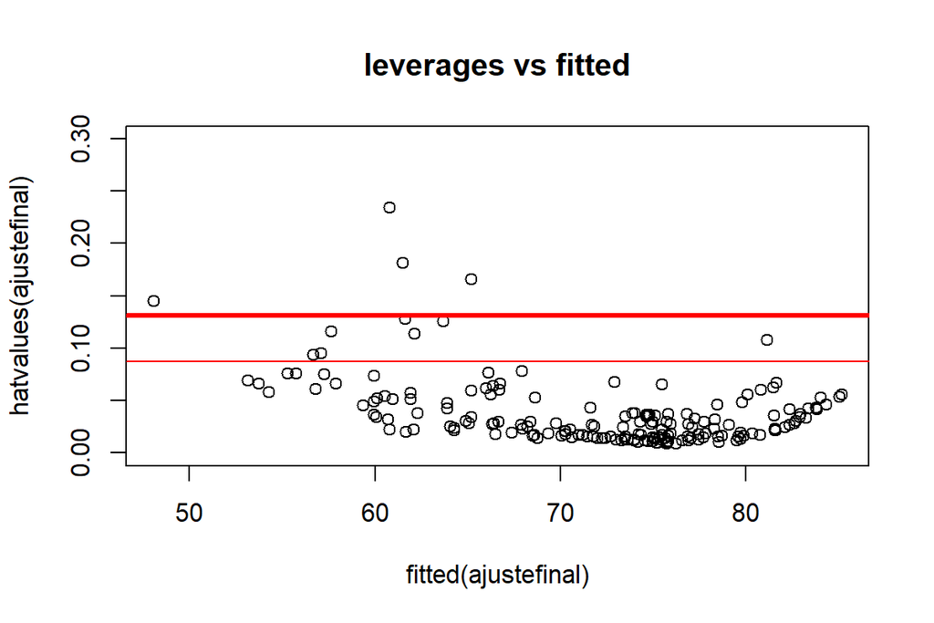

```
Call:
lm(formula = (Life.expectancy ~ Total.expenditure + poly(HIV.AIDS,
    2) + poly(Adult.Mortality, 2) + poly(Income.composition.of.resources,
    2)), data = Imputed_data[setdiff(rownames(Imputed_data),
    Infl), ])

Residuals:
    Min      1Q  Median      3Q     Max
-7.8856 -1.3313 -0.3377  1.4914  6.0962

Coefficients:
                                           Estimate Std. Error t value Pr(>|t|)
(Intercept)                                69.32850    0.43620 158.936  < 2e-16 ***
Total.expenditure                           0.31191    0.06515   4.788 3.71e-06 ***
poly(HIV.AIDS, 2)1                         -3.28389    3.73825  -0.878 0.380967
poly(HIV.AIDS, 2)2                         16.26031    2.62608   6.192 4.51e-09 ***
poly(Adult.Mortality, 2)1                 -35.90104    3.99650  -8.983 5.60e-16 ***
poly(Adult.Mortality, 2)2                 -23.19317    3.26972  -7.093 3.60e-11 ***
poly(Income.composition.of.resources, 2)1  61.91475    3.43904  18.004  < 2e-16 ***
poly(Income.composition.of.resources, 2)2   9.36806    2.45831   3.811 0.000195 ***
---
Signif. codes:  0 '***' 0.001 '**' 0.01 '*' 0.05 '.' 0.1 ' ' 1

Residual standard error: 2.258 on 166 degrees of freedom
Multiple R-squared:  0.926, Adjusted R-squared:  0.9229
F-statistic: 296.8 on 7 and 166 DF,  p-value: < 2.2e-16
```

```
                                             GVIF Df GVIF^(1/(2*Df))
Total.expenditure                        1.081523  1        1.039963
poly(HIV.AIDS, 2)                        3.621576  2        1.379509
poly(Adult.Mortality, 2)                 5.255235  2        1.514077
poly(Income.composition.of.resources, 2) 2.697612  2        1.281578
```

Tampoco tenemos problemas de colinealidad, así que, nos quedaremos con este modelo para las predicciones.

## Predicción

Imputamos también los datos faltantes del 2015. Utilzamos de nuevo el paquete mice, excepto para la columna Total.expenditure, para la que copiamos los datos del año anterior.

```r
mice_imputes_2015 = mice(EV2015, m=1, maxit = 50, seed = 500)
Imputed_data_2015 =complete(mice_imputes_2015)
Imputed_data_2015$Total.expenditure <- Imputed_data$Total.expenditure
```

Hacemos la predicción y la guardamos en un archivo RData.

```r
x0 <- Imputed_data_2015 %>% select(c('Country', 'Adult.Mortality', 'HIV.AIDS', 'Income.composition.of.resources', 'Total.expenditure'))
predicted <- predict(ajuste_sinInfl, newdata = x0)
```

```r
data <-  data.frame(Country = Imputed_data_2015$Country, Predictions = predicted)
save(data, file = "predictions.RData")
#View(data)
```

Exportamos el archivo csv

```r
write.csv(data$Predictions,"predictions.csv",row.names = FALSE)
```